title: “Assessment 1” author: “Jashanjot Kaur , s4668741” date: “11/12/2021” output: html_document

### RMarkdown ## Turn your analyses into high quality documents, reports, presentations and dashboards.R Markdown documents are fully reproducible. Use a productive notebook interface to weave together narrative text and code to produce elegantly formatted output.

```r
library(tidyverse)
library(knitr)
library(skimr)
```

## Insert an R chunk and create a variable with this dataset

https://raw.githubusercontent.com/rfordatascience/tidytuesday/master/data/2018/2018-09-04/fastfood_calories.csv

## The name of the variable should be `fastfood`

```r
fastfood <-read_csv ('https://raw.githubusercontent.com/rfordatascience/tidytuesday/master/data/2018/2018-09-04/fastfood_calories.csv')
```

```
## * `` -> ...1
```

## Display the first 10 rows of the dataset using head() and kable().

## Display the first 10 rows of the dataset and the first 5 variables

```r
kable(head(fastfood,10), "pipe")
```

| …1 | restaurant | item | calories | cal_fat | total_fat | sat_fat | trans_fat | cholesterol | sodium | total_carb | fiber | sugar | protein | vit_a | vit_c | calcium | salad |
| --- | --- | --- | --- | --- | --- | --- | --- | --- | --- | --- | --- | --- | --- | --- | --- | --- | --- |
| 1 | Mcdonalds | Artisan Grilled Chicken Sandwich | 380 | 60 | 7 | 2 | 0.0 | 95 | 1110 | 44 | 3 | 11 | 37 | 4 | 20 | 20 | Other |
| 2 | Mcdonalds | Single Bacon Smokehouse Burger | 840 | 410 | 45 | 17 | 1.5 | 130 | 1580 | 62 | 2 | 18 | 46 | 6 | 20 | 20 | Other |
| 3 | Mcdonalds | Double Bacon Smokehouse Burger | 1130 | 600 | 67 | 27 | 3.0 | 220 | 1920 | 63 | 3 | 18 | 70 | 10 | 20 | 50 | Other |
| 4 | Mcdonalds | Grilled Bacon Smokehouse Chicken Sandwich | 750 | 280 | 31 | 10 | 0.5 | 155 | 1940 | 62 | 2 | 18 | 55 | 6 | 25 | 20 | Other |
| 5 | Mcdonalds | Crispy Bacon Smokehouse Chicken Sandwich | 920 | 410 | 45 | 12 | 0.5 | 120 | 1980 | 81 | 4 | 18 | 46 | 6 | 20 | 20 | Other |
| 6 | Mcdonalds | Big Mac | 540 | 250 | 28 | 10 | 1.0 | 80 | 950 | 46 | 3 | 9 | 25 | 10 | 2 | 15 | Other |
| 7 | Mcdonalds | Cheeseburger | 300 | 100 | 12 | 5 | 0.5 | 40 | 680 | 33 | 2 | 7 | 15 | 10 | 2 | 10 | Other |
| 8 | Mcdonalds | Classic Chicken Sandwich | 510 | 210 | 24 | 4 | 0.0 | 65 | 1040 | 49 | 3 | 6 | 25 | 0 | 4 | 2 | Other |
| 9 | Mcdonalds | Double Cheeseburger | 430 | 190 | 21 | 11 | 1.0 | 85 | 1040 | 35 | 2 | 7 | 25 | 20 | 4 | 15 | Other |
| 10 | Mcdonalds | Double Quarter Pounder® with Cheese | 770 | 400 | 45 | 21 | 2.5 | 175 | 1290 | 42 | 3 | 10 | 51 | 20 | 6 | 20 | Other |

```r
kable(fastfood[1:10,1:5])
```

| …1 | restaurant | item | calories | cal_fat |
| --- | --- | --- | --- | --- |
| 1 | Mcdonalds | Artisan Grilled Chicken Sandwich | 380 | 60 |
| 2 | Mcdonalds | Single Bacon Smokehouse Burger | 840 | 410 |
| 3 | Mcdonalds | Double Bacon Smokehouse Burger | 1130 | 600 |
| 4 | Mcdonalds | Grilled Bacon Smokehouse Chicken Sandwich | 750 | 280 |
| 5 | Mcdonalds | Crispy Bacon Smokehouse Chicken Sandwich | 920 | 410 |
| 6 | Mcdonalds | Big Mac | 540 | 250 |
| 7 | Mcdonalds | Cheeseburger | 300 | 100 |
| 8 | Mcdonalds | Classic Chicken Sandwich | 510 | 210 |
| 9 | Mcdonalds | Double Cheeseburger | 430 | 190 |
| 10 | Mcdonalds | Double Quarter Pounder® with Cheese | 770 | 400 |

## Display the observations that has more than 1000 calories

```r
fastfood%>%
filter(calories>1000)
```

```
## # A tibble: 28 x 18
##     ...1 restaurant item            calories cal_fat total_fat sat_fat trans_fat
##    <dbl> <chr>      <chr>              <dbl>   <dbl>     <dbl>   <dbl>     <dbl>
##  1     3 Mcdonalds  Double Bacon S~     1130     600        67      27       3
##  2    38 Mcdonalds  10 piece Butte~     1210     630        70      12       1
##  3    39 Mcdonalds  12 piece Butte~     1510     790        88      15       1
##  4    40 Mcdonalds  20 piece Butte~     2430    1270       141      24       2
##  5    45 Mcdonalds  40 piece Chick~     1770     960       107      18       0.5
##  6    48 Mcdonalds  10 piece Sweet~     1600     600        66      10       0
##  7    99 Sonic      Super Sonic Ba~     1280     830        92      36       4
##  8   100 Sonic      Super Sonic Do~     1120     680        76      32       4
##  9   101 Sonic      Super Sonic Do~     1130     680        76      32       4
## 10   102 Sonic      Super Sonic Do~     1220     780        87      34       4
## # ... with 18 more rows, and 10 more variables: cholesterol <dbl>,
## #   sodium <dbl>, total_carb <dbl>, fiber <dbl>, sugar <dbl>, protein <dbl>,
## #   vit_a <dbl>, vit_c <dbl>, calcium <dbl>, salad <chr>
```

## Arrange observations with more than 40 in total_fat and more than 80 in total_carb in the descending order and save them to a new variable (dataset) called `dont_eat_this`

# In arranging the variables, the only one variable out of two will arrange in the descending order. the function will not work for both of the variables.

```r
`dont_eat_this`<- fastfood %>%
 arrange(desc(total_fat,total_carb))%>%
  filter(total_fat>40 ,total_carb>80)
```

## Using the initial dataset variable, use `case_when()` to create a new variable `heavy_food` which is equal to “heavy” when total calories are greater than 500, “low” when total calories are less than 250 and “average” for all other cases. Count the number of observations in each created category.

```r
fastfood%>%
  select(restaurant,item,calories)%>%
  mutate(heavy_food=case_when(calories>"500"~ "heavy",calories<"250"~"low",T~"average"))
```

```
## # A tibble: 515 x 4
##    restaurant item                                      calories heavy_food
##    <chr>      <chr>                                        <dbl> <chr>
##  1 Mcdonalds  Artisan Grilled Chicken Sandwich               380 average
##  2 Mcdonalds  Single Bacon Smokehouse Burger                 840 heavy
##  3 Mcdonalds  Double Bacon Smokehouse Burger                1130 low
##  4 Mcdonalds  Grilled Bacon Smokehouse Chicken Sandwich      750 heavy
##  5 Mcdonalds  Crispy Bacon Smokehouse Chicken Sandwich       920 heavy
##  6 Mcdonalds  Big Mac                                        540 heavy
##  7 Mcdonalds  Cheeseburger                                   300 average
##  8 Mcdonalds  Classic Chicken Sandwich                       510 heavy
##  9 Mcdonalds  Double Cheeseburger                            430 average
## 10 Mcdonalds  Double Quarter Pounder® with Cheese            770 heavy
## # ... with 505 more rows
```

## Display the types of variables in the dataset using `skimr` package

```r
 skim(fastfood)
```

Data summary

| Name | fastfood |
| --- | --- |
| Number of rows | 515 |
| Number of columns | 18 |
| _______________________ |  |
| Column type frequency: |  |
| character | 3 |
| numeric | 15 |
| ________________________ |  |
| Group variables | None |

**Variable type: character**

| skim_variable | n_missing | complete_rate | min | max | empty | n_unique | whitespace |
| --- | --- | --- | --- | --- | --- | --- | --- |
| restaurant | 0 | 1 | 5 | 11 | 0 | 8 | 0 |
| item | 0 | 1 | 5 | 63 | 0 | 505 | 0 |
| salad | 0 | 1 | 5 | 5 | 0 | 1 | 0 |

**Variable type: numeric**

| skim_variable | n_missing | complete_rate | mean | sd | p0 | p25 | p50 | p75 | p100 | hist |
| --- | --- | --- | --- | --- | --- | --- | --- | --- | --- | --- |
| …1 | 0 | 1.00 | 258.00 | 148.81 | 1 | 129.5 | 258.0 | 386.5 | 515 | ▇▇▇▇▇ |
| calories | 0 | 1.00 | 530.91 | 282.44 | 20 | 330.0 | 490.0 | 690.0 | 2430 | ▇▆▁▁▁ |
| cal_fat | 0 | 1.00 | 238.81 | 166.41 | 0 | 120.0 | 210.0 | 310.0 | 1270 | ▇▃▁▁▁ |
| total_fat | 0 | 1.00 | 26.59 | 18.41 | 0 | 14.0 | 23.0 | 35.0 | 141 | ▇▃▁▁▁ |
| sat_fat | 0 | 1.00 | 8.15 | 6.42 | 0 | 4.0 | 7.0 | 11.0 | 47 | ▇▃▁▁▁ |
| trans_fat | 0 | 1.00 | 0.47 | 0.84 | 0 | 0.0 | 0.0 | 1.0 | 8 | ▇▁▁▁▁ |
| cholesterol | 0 | 1.00 | 72.46 | 63.16 | 0 | 35.0 | 60.0 | 95.0 | 805 | ▇▁▁▁▁ |
| sodium | 0 | 1.00 | 1246.74 | 689.95 | 15 | 800.0 | 1110.0 | 1550.0 | 6080 | ▇▆▁▁▁ |
| total_carb | 0 | 1.00 | 45.66 | 24.88 | 0 | 28.5 | 44.0 | 57.0 | 156 | ▅▇▂▁▁ |
| fiber | 12 | 0.98 | 4.14 | 3.04 | 0 | 2.0 | 3.0 | 5.0 | 17 | ▇▅▂▁▁ |
| sugar | 0 | 1.00 | 7.26 | 6.76 | 0 | 3.0 | 6.0 | 9.0 | 87 | ▇▁▁▁▁ |
| protein | 1 | 1.00 | 27.89 | 17.68 | 1 | 16.0 | 24.5 | 36.0 | 186 | ▇▂▁▁▁ |
| vit_a | 214 | 0.58 | 18.86 | 31.38 | 0 | 4.0 | 10.0 | 20.0 | 180 | ▇▁▁▁▁ |
| vit_c | 210 | 0.59 | 20.17 | 30.59 | 0 | 4.0 | 10.0 | 30.0 | 400 | ▇▁▁▁▁ |
| calcium | 210 | 0.59 | 24.85 | 25.52 | 0 | 8.0 | 20.0 | 30.0 | 290 | ▇▁▁▁▁ |

## Present the count observations from each restaurant in a descending order

## Show the number of distnct items on a menu in the dataset

```r
fastfood%>%
  count(restaurant,sort= TRUE)%>%
  arrange(desc(n))%>%
  kable()
```

| restaurant | n |
| --- | --- |
| Taco Bell | 115 |
| Subway | 96 |
| Burger King | 70 |
| Mcdonalds | 57 |
| Arbys | 55 |
| Sonic | 53 |
| Dairy Queen | 42 |
| Chick Fil-A | 27 |

```r
  n_distinct(fastfood$item)
```

```
## [1] 505
```

## Using groupings (group_by()), summarise and display the average number of calories for each restaurant.

```r
fastfood%>%
  group_by(restaurant)%>%
  summarise(average_calories = mean(calories))%>%
  ungroup()%>%
  kable()
```

| restaurant | average_calories |
| --- | --- |
| Arbys | 532.7273 |
| Burger King | 608.5714 |
| Chick Fil-A | 384.4444 |
| Dairy Queen | 520.2381 |
| Mcdonalds | 640.3509 |
| Sonic | 631.6981 |
| Subway | 503.0208 |
| Taco Bell | 443.6522 |

## Add variables to the dataset, which:

- calculates the average calories per type of restaurant and call it `average_calories`
- calculates the maximum total_fat per type of restaurant and call it `max_fat` - calculates the minimum cholesterol per type of restaurant and call it `min_cholesterol`

```r
 fastfood%>%
   select(restaurant,calories,cholesterol,total_fat)%>%
   group_by(restaurant)%>%
   mutate(average_calories= mean(calories),max_fat=max(total_fat),min_cholesterol=min(cholesterol))%>%
   ungroup()
```

```
## # A tibble: 515 x 7
##    restaurant calories cholesterol total_fat average_calories max_fat
##    <chr>         <dbl>       <dbl>     <dbl>            <dbl>   <dbl>
##  1 Mcdonalds       380          95         7             640.     141
##  2 Mcdonalds       840         130        45             640.     141
##  3 Mcdonalds      1130         220        67             640.     141
##  4 Mcdonalds       750         155        31             640.     141
##  5 Mcdonalds       920         120        45             640.     141
##  6 Mcdonalds       540          80        28             640.     141
##  7 Mcdonalds       300          40        12             640.     141
##  8 Mcdonalds       510          65        24             640.     141
##  9 Mcdonalds       430          85        21             640.     141
## 10 Mcdonalds       770         175        45             640.     141
## # ... with 505 more rows, and 1 more variable: min_cholesterol <dbl>
```

## Display the data vis of total fat per each type of restaurant. Write a narration (2-3 sentences) why you believe this type of data viz presents such information best.

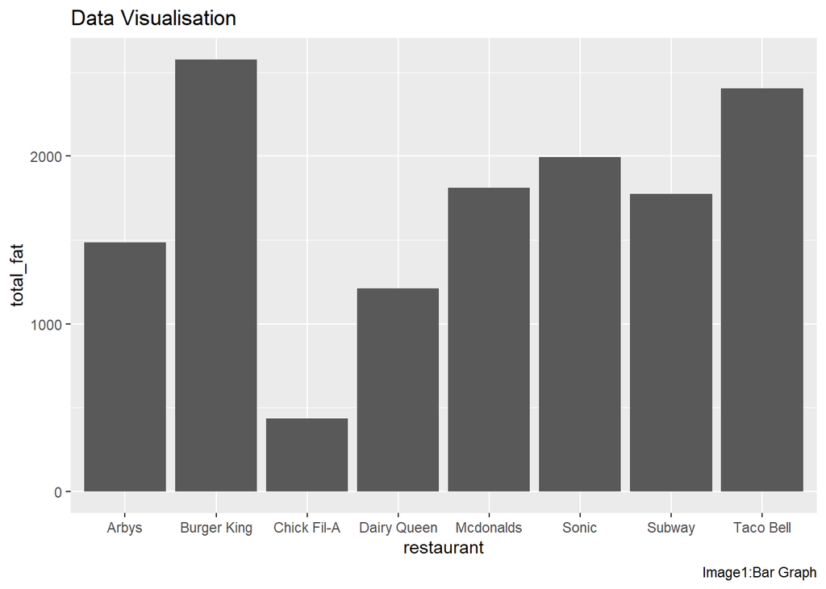

```r
 fastfood%>%
   group_by(restaurant)%>%
   ungroup()%>%
   ggplot(aes(restaurant,total_fat))+
   geom_col()+
   labs(title = "Data Visualisation", caption = "Image1:Bar Graph")
```

## Add a variable to the dataset, which calculates the sum of cholesterol and sodium and call it `cholesterol_sodium`.

```r
fastfood%>%
   select(restaurant,item,sodium,cholesterol)%>%
   mutate(cholesterol_sodium=sum(sodium,cholesterol))
```

```
## # A tibble: 515 x 5
##    restaurant item                          sodium cholesterol cholesterol_sodi~
##    <chr>      <chr>                          <dbl>       <dbl>             <dbl>
##  1 Mcdonalds  Artisan Grilled Chicken Sand~   1110          95            679385
##  2 Mcdonalds  Single Bacon Smokehouse Burg~   1580         130            679385
##  3 Mcdonalds  Double Bacon Smokehouse Burg~   1920         220            679385
##  4 Mcdonalds  Grilled Bacon Smokehouse Chi~   1940         155            679385
##  5 Mcdonalds  Crispy Bacon Smokehouse Chic~   1980         120            679385
##  6 Mcdonalds  Big Mac                          950          80            679385
##  7 Mcdonalds  Cheeseburger                     680          40            679385
##  8 Mcdonalds  Classic Chicken Sandwich        1040          65            679385
##  9 Mcdonalds  Double Cheeseburger             1040          85            679385
## 10 Mcdonalds  Double Quarter Pounder® with~   1290         175            679385
## # ... with 505 more rows
```

```r
## to remove variable salad
fastfood%>%
select(-salad)
```

```
## # A tibble: 515 x 17
##     ...1 restaurant item            calories cal_fat total_fat sat_fat trans_fat
##    <dbl> <chr>      <chr>              <dbl>   <dbl>     <dbl>   <dbl>     <dbl>
##  1     1 Mcdonalds  Artisan Grille~      380      60         7       2       0
##  2     2 Mcdonalds  Single Bacon S~      840     410        45      17       1.5
##  3     3 Mcdonalds  Double Bacon S~     1130     600        67      27       3
##  4     4 Mcdonalds  Grilled Bacon ~      750     280        31      10       0.5
##  5     5 Mcdonalds  Crispy Bacon S~      920     410        45      12       0.5
##  6     6 Mcdonalds  Big Mac              540     250        28      10       1
##  7     7 Mcdonalds  Cheeseburger         300     100        12       5       0.5
##  8     8 Mcdonalds  Classic Chicke~      510     210        24       4       0
##  9     9 Mcdonalds  Double Cheeseb~      430     190        21      11       1
## 10    10 Mcdonalds  Double Quarter~      770     400        45      21       2.5
## # ... with 505 more rows, and 9 more variables: cholesterol <dbl>,
## #   sodium <dbl>, total_carb <dbl>, fiber <dbl>, sugar <dbl>, protein <dbl>,
## #   vit_a <dbl>, vit_c <dbl>, calcium <dbl>
```

## Use observations for Mcdonalds to plot sugar variable against protein with `geom_point()`

There are some missing values in variable protein. So, first i have to filter is out first.

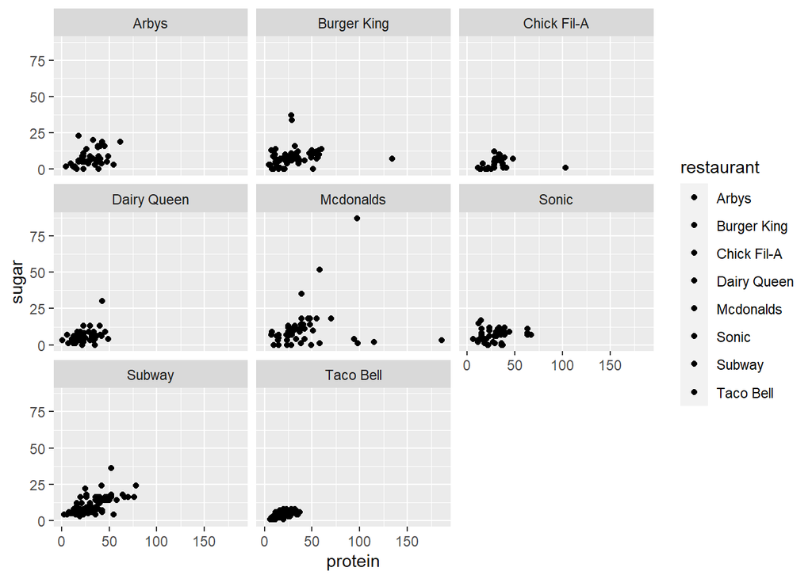

```r
fastfood%>%
  filter(protein!="NA")%>%
  group_by(restaurant)%>%
   ungroup()%>%
  ggplot(aes(protein,sugar,fill=restaurant))+
  geom_point()+
  facet_wrap(~restaurant)
```

## Identify variable(s) which should be factors and transform their type into a factor variable.

```r
skim(fastfood)
```

Data summary

| Name | fastfood |
| --- | --- |
| Number of rows | 515 |
| Number of columns | 18 |
| _______________________ |  |
| Column type frequency: |  |
| character | 3 |
| numeric | 15 |
| ________________________ |  |
| Group variables | None |

**Variable type: character**

| skim_variable | n_missing | complete_rate | min | max | empty | n_unique | whitespace |
| --- | --- | --- | --- | --- | --- | --- | --- |
| restaurant | 0 | 1 | 5 | 11 | 0 | 8 | 0 |
| item | 0 | 1 | 5 | 63 | 0 | 505 | 0 |
| salad | 0 | 1 | 5 | 5 | 0 | 1 | 0 |

**Variable type: numeric**

| skim_variable | n_missing | complete_rate | mean | sd | p0 | p25 | p50 | p75 | p100 | hist |
| --- | --- | --- | --- | --- | --- | --- | --- | --- | --- | --- |
| …1 | 0 | 1.00 | 258.00 | 148.81 | 1 | 129.5 | 258.0 | 386.5 | 515 | ▇▇▇▇▇ |
| calories | 0 | 1.00 | 530.91 | 282.44 | 20 | 330.0 | 490.0 | 690.0 | 2430 | ▇▆▁▁▁ |
| cal_fat | 0 | 1.00 | 238.81 | 166.41 | 0 | 120.0 | 210.0 | 310.0 | 1270 | ▇▃▁▁▁ |
| total_fat | 0 | 1.00 | 26.59 | 18.41 | 0 | 14.0 | 23.0 | 35.0 | 141 | ▇▃▁▁▁ |
| sat_fat | 0 | 1.00 | 8.15 | 6.42 | 0 | 4.0 | 7.0 | 11.0 | 47 | ▇▃▁▁▁ |
| trans_fat | 0 | 1.00 | 0.47 | 0.84 | 0 | 0.0 | 0.0 | 1.0 | 8 | ▇▁▁▁▁ |
| cholesterol | 0 | 1.00 | 72.46 | 63.16 | 0 | 35.0 | 60.0 | 95.0 | 805 | ▇▁▁▁▁ |
| sodium | 0 | 1.00 | 1246.74 | 689.95 | 15 | 800.0 | 1110.0 | 1550.0 | 6080 | ▇▆▁▁▁ |
| total_carb | 0 | 1.00 | 45.66 | 24.88 | 0 | 28.5 | 44.0 | 57.0 | 156 | ▅▇▂▁▁ |
| fiber | 12 | 0.98 | 4.14 | 3.04 | 0 | 2.0 | 3.0 | 5.0 | 17 | ▇▅▂▁▁ |
| sugar | 0 | 1.00 | 7.26 | 6.76 | 0 | 3.0 | 6.0 | 9.0 | 87 | ▇▁▁▁▁ |
| protein | 1 | 1.00 | 27.89 | 17.68 | 1 | 16.0 | 24.5 | 36.0 | 186 | ▇▂▁▁▁ |
| vit_a | 214 | 0.58 | 18.86 | 31.38 | 0 | 4.0 | 10.0 | 20.0 | 180 | ▇▁▁▁▁ |
| vit_c | 210 | 0.59 | 20.17 | 30.59 | 0 | 4.0 | 10.0 | 30.0 | 400 | ▇▁▁▁▁ |
| calcium | 210 | 0.59 | 24.85 | 25.52 | 0 | 8.0 | 20.0 | 30.0 | 290 | ▇▁▁▁▁ |

```r
fastfood$restaurant<-as_factor(fastfood$restaurant)
fastfood$item<-as_factor(fastfood$item)
fastfood$salad<-as_factor(fastfood$salad)

class(fastfood$restaurant)
```

```
## [1] "factor"
```

```r
class(fastfood$item)
```

```
## [1] "factor"
```

```r
class(fastfood$salad)
```

```
## [1] "factor"
```

Create two new variables:

## Read about `cut_number()` function using Help and add a new variable to the dataset `calories_type`. Use `calories` variable for `cut_number()` function to split it into 3 categories `n=3`, add labels `labels=c("low", "med", "high")` and make the dataset ordered by arranging it according to calories.

```r
  table(fastfood$calories)%>%
 cut(breaks=3,labels=c("low", "med", "high"))
```

```
##   [1] low  low  low  low  low  low  low  med  med  low  low  low  low  high med
##  [16] low  med  low  low  low  med  med  med  med  med  high med  med  high low
##  [31] med  high med  med  med  med  high med  high low  med  med  med  low  low
##  [46] med  med  high high med  med  high low  med  low  low  med  high med  low
##  [61] low  low  low  low  med  med  med  med  low  med  low  med  low  low  low
##  [76] low  low  low  low  low  low  low  low  low  low  low  low  low  low  low
##  [91] low  low  low  low  low  low  low  low  low  low  low  low  low  low  low
## [106] low  low  low  low  low  low  low  low
## Levels: low med high
```

I didn’t get the point, how cut_number function will work? so,i use another function to perform this task. But in this function ,i am not able to save the new variable in the data. that”s why i am leaving this question here and also didn’t able to complete the next question.

## The second variable should show the percentage of `trans_fat` in `total_fat`. Add the variable to the dataset and call it `trans_fat_percent`.

```r
 new_data<-fastfood%>%
  mutate(trans_fat_percent=mean(trans_fat))
```

## Create a dataviz that shows the distribution of `trans_fat` in food items for each type of restaurant.

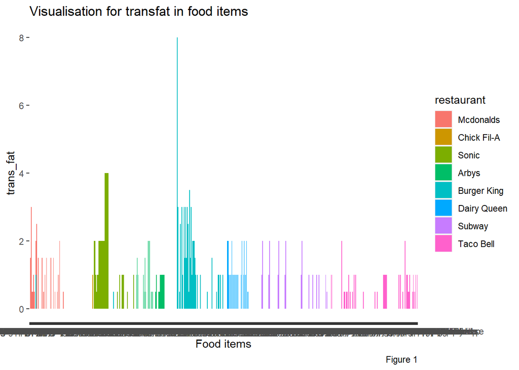

```r
    fastfood%>%
      group_by(restaurant,item)%>%
      ungroup()%>%
      ggplot(aes(item,trans_fat,fill=restaurant))+
      geom_col()+
      labs(title= "Visualisation for transfat in food items ",x="Food items",caption= "Figure 1")
```

## Calculate and show the average (mean) `total_fat` for each type of restaurant. No need to save it as a variable.

```r
fastfood%>%
  group_by(restaurant)%>%
  summarise(averagetotal_fat=mean(total_fat))%>%
  ungroup()%>%
  kable()
```

| restaurant | averagetotal_fat |
| --- | --- |
| Mcdonalds | 31.80702 |
| Chick Fil-A | 16.14815 |
| Sonic | 37.64151 |
| Arbys | 26.98182 |
| Burger King | 36.81429 |
| Dairy Queen | 28.85714 |
| Subway | 18.47917 |
| Taco Bell | 20.89565 |

## create a dataviz that allow to compare different restaurants on this variable (`total_fat`).

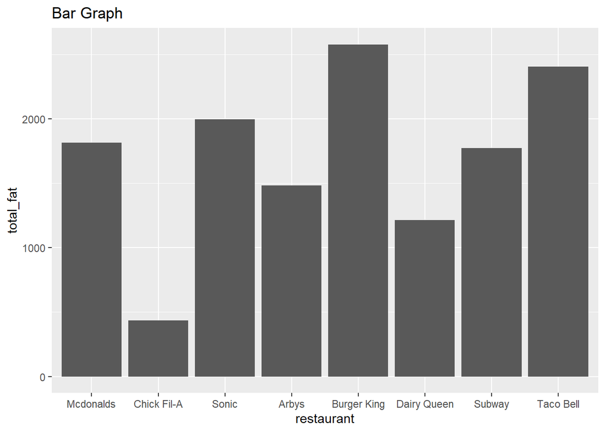

```r
fastfood%>%
  ggplot(aes(restaurant,total_fat))+
  geom_col()+
  labs(title="Bar Graph")
```